# Variáveis Aleatórias

### Exercícios a seguir englobam variáveis aleatórias contínuas

Carregando algumas bibliotecas:

```python
%matplotlib inline
import pandas as pd
import matplotlib.pyplot as plt
import numpy as np

from scipy import stats
import math

# Para ter melhor print
from IPython.display import display
```

## Índice

- Questão 1 - Vendas do telemarketing (Modelo Teórico)
  - Item a
  - Item b
  - Item c
  - Item d
- Questão 2 - Vendas do telemarketing (Dados)
  - Item a
  - Item b
  - Item c
  - Item d
  - Item e
- Questão 3 - Vida útil dos drives de Blu-ray (Modelo Teórico)
  - Item a
  - Item b
  - Item c
  - Item d
  - Item e
  - Item f
- Questão 4 - Vida útil dos drives de Blu-ray (Dados)
  - Item a
  - Item b
  - Item c
- Questão 5 - Doceria
  - Item a
  - Item b
- Questão 6 - Contagem de leucócitos
  - Item a
  - Item b
  - Item c
- Questão 7 - Análise do ENEM
  - Item a
  - Item b
  - Item c
  - Item d
  - Item e
  - Item f

# Questão 1

No artigo de [Moro et al (2014)](https://www.researchgate.net/publication/260805594_A_Data-Driven_Approach_to_Predict_the_Success_of_Bank_Telemarketing), o intuito é prever o sucesso de vendas do telemarketing na venda de um produto bancário, considerando clientes de um banco português abordados entre 2008 e 2013.

Para cada cliente, foram mensurados o tempo de duração do contato telefônico (em segundos) e a venda ou não do produto bancário oferecido.

Assuma que $X$ seja o tempo de duração do contato telefônico (em segundos) de um cliente qualquer modelado por uma exponencial com média igual a $264$ segundos.

Com base nesse modelo, responda:

**a)** Quando um cliente conversa mais do que 5 minutos, qual a probabilidade de não passar de 6 minutos?

```python
# Coloque seu código aqui...
```

```python
# PROF
# P(X<6*60 | X>5*60) = (P(X<6*60) - P(X<5*60))/(1-P(X>5*60))

mu = 264
num = stats.expon.cdf(6*60, scale=mu)-stats.expon.cdf(5*60, scale=mu)
denom = 1-stats.expon.cdf(5*60, scale=mu)

f'P(X<6*60 | X>5*60) = {num/denom:.6f}'
```

```
'P(X<6*60 | X>5*60) = 0.203297'
```

**b)** Qual tempo mínimo de duração do contato telefônico (em segundos) das $5\%$ conversas mais demoradas?

```python
# Coloque seu código aqui...
```

```python
# PROF
tmin=stats.expon.ppf(0.95, scale=mu)

f'Tempo mínimo das 5% conversas mais demoradas = {tmin:.2f} segundos'
```

```
'Tempo mínimo das 5% conversas mais demoradas = 790.87 segundos'
```

**c)** Uma atendente de telemarketing precisa ligar para 10 clientes para ofertar esse produto bancário. Qual a probabilidade de que nenhum desses 10 clientes conversem mais do que 5 minutos no contato telefônico?

```python
# Coloque seu código aqui...
```

```python
# PROF
p = 1-stats.expon.cdf(5*60, scale=mu)
f'Probabilidade de sucesso: P(X>300)=p={p:.5f}'
```

```
'Probabilidade de sucesso: P(X>300)=p=0.32098'
```

```python
# PROF
print(f'Y: numero de clientes que conversem mais do que 5 minutos '
      'no contato telefônico entre esses 10 clientes')
print(f'Y ~ Bin(10;{p:.5f})')

prob = stats.binom.pmf(0, 10, p)
print(f'P(Y=0)={prob:.5f}')
```

```
Y: numero de clientes que conversem mais do que 5 minutos no contato telefônico entre esses 10 clientes
Y ~ Bin(10;0.32098)
P(Y=0)=0.02084
```

**d)** Assuma que o número de vendas por dia desse produto bancário seja, em média, igual a 12 vendas. Suponha que:

- As vendas são independentes entre si;
- Os dias se comportam de maneira semelhante uns aos outros.

Atribuindo um modelo probabilístico adequado a essa variável, encontre o percentil de ordem $25\%$.

```python
# Coloque seu código aqui...
```

```python
# PROF
print(f'W: numero de vendas diária desse produto bancário')
print(f'W ~ Poisson(12)')

mu_vendas = 12
q1 = stats.poisson.ppf(0.25, mu=mu_vendas)
print(f'P(W<=Q1)=25% então Q1={q1}')
```

```
W: numero de vendas diária desse produto bancário
W ~ Poisson(12)
P(W<=Q1)=25% então Q1=10.0
```

# Questão 2

Nesta questão, vamos considerar a base de dados utilizada em [Moro et al (2014)](https://www.researchgate.net/publication/260805594_A_Data-Driven_Approach_to_Predict_the_Success_of_Bank_Telemarketing).

```python
filename = 'bank.csv'
dados = pd.read_csv(filename, sep=";")
```

```python
dados.head()
```

|  | age | job | marital | education | default | balance | housing | loan | contact | day | month | duration | campaign | pdays | previous | poutcome | y |
| --- | --- | --- | --- | --- | --- | --- | --- | --- | --- | --- | --- | --- | --- | --- | --- | --- | --- |
| 0 | 30 | unemployed | married | primary | no | 1787 | no | no | cellular | 19 | oct | 79 | 1 | -1 | 0 | unknown | no |
| 1 | 33 | services | married | secondary | no | 4789 | yes | yes | cellular | 11 | may | 220 | 1 | 339 | 4 | failure | no |
| 2 | 35 | management | single | tertiary | no | 1350 | yes | no | cellular | 16 | apr | 185 | 1 | 330 | 1 | failure | no |
| 3 | 30 | management | married | tertiary | no | 1476 | yes | yes | unknown | 3 | jun | 199 | 4 | -1 | 0 | unknown | no |
| 4 | 59 | blue-collar | married | secondary | no | 0 | yes | no | unknown | 5 | may | 226 | 1 | -1 | 0 | unknown | no |

**SIGNIFICADO DAS VARIÁVEIS:**

Dentre todas essas variáveis (com nome em inglês) apresentadas nessa base de dados, vamos trabalhar com apenas as seguintes colunas:

- `duration`: tempo de duração da chamada telefônica para oferecer produto bancário (em segundos)
- `y`: adesão ou não do produto oferecido pelo contato telefônico (com as categorias: 'yes' e 'no')

**PERGUNTA:**

Nesta questão, o objetivo será avaliar se `duration` segmentanda pela variável `y` pode ser modelada por uma distribuição exponencial.

**a) Crie duas pd.Series**: uma contendo o tempo de duração apenas dos clientes que **não fizeram** adesão ao produto e guarde em `duration_no`; e outra contendo o tempo de duração apenas dos clientes que **fizeram** adesão ao produto e guarde em `duration_yes`;

```python
# Coloque seu código aqui...
```

```python
# PROF
# Filtro da base de dados
duration_no = dados.loc[dados.y=='no','duration']
duration_yes = dados.loc[dados.y=='yes','duration']
```

**b) Construa dois histogramas** de densidade: um considerando `duration_no` e outro considerando `duration_yes`. Faça uso de `plt.subplot()` adequadamente;

```python
# Coloque seu código aqui...
```

```python
dados.duration.describe()
```

```
count    4521.000000
mean      263.961292
std       259.856633
min         4.000000
25%       104.000000
50%       185.000000
75%       329.000000
max      3025.000000
Name: duration, dtype: float64
```

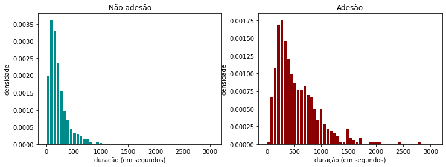

```python
# PROF
plt.figure(figsize=(12, 4))

plt.subplot(121)

faixa = np.arange(0, 3062, 60)
plt.hist(duration_no, bins=faixa, edgecolor='white',density=True, color='darkcyan')
plt.title('Não adesão')
plt.ylabel('densidade')
plt.xlabel('duração (em segundos)')

plt.subplot(122)

plt.hist(duration_yes, bins=faixa, edgecolor='white',density=True, color='darkred')
plt.title('Adesão')
plt.ylabel('densidade')
plt.xlabel('duração (em segundos)')

plt.show()
```

**c)** Para cada série **estime o parâmetro $\mu$ da exponencial** considerando os valores da série;

```python
mu_no = duration_no.mean()
mu_yes = duration_yes.mean()
f'mu_estimado No = {mu_no} e mu_estimado Yes = {mu_yes}'
```

```
'mu_estimado No = 226.3475 e mu_estimado Yes = 552.7428023032629'
```

**d) Calcule a função densidade de probabilidade (f.d.p.) da exponencial** para valores do tempo de duração compatíveis com os histogramas anteriores, e assumindo as respectivas estimativas de $\mu$ obtidas no item anterior;

```python
x_no = np.linspace(0, 3060 , 1000)
fx_no = stats.expon.pdf(x_no, scale=mu_no)
```

```python
x_yes = np.linspace(0, 3060 , 1000)
fx_yes = stats.expon.pdf(x_yes, scale=mu_yes)
```

**e) Visualize cada f.d.p.** calculada anteriormente sobre seu respectivo histograma de densidade obtido a partir dos dados.

```python
# Coloque seu código aqui...
```

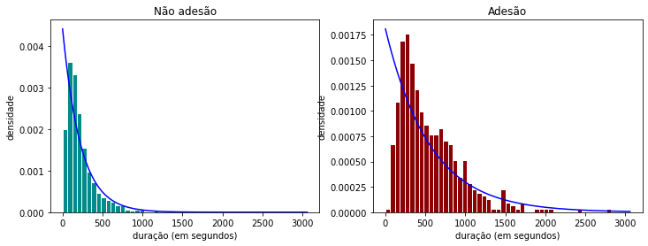

```python
# PROF
# OPCAO com histograma + fdp
faixa = np.arange(0, 3062, 60)

plt.figure(figsize=(12, 4))

plt.subplot(121)
plt.plot(x_no, fx_no, color='blue')
plt.hist(duration_no, bins=faixa, edgecolor='white',density=True, color='darkcyan')

plt.title('Não adesão')
plt.ylabel('densidade')
plt.xlabel('duração (em segundos)')


plt.subplot(122)

plt.plot(x_yes, fx_yes, color='blue')
plt.hist(duration_yes, bins=faixa, edgecolor='white',density=True, color='darkred')

plt.title('Adesão')
plt.ylabel('densidade')
plt.xlabel('duração (em segundos)')


plt.show()
```

# Questão 3

[figure not shown]

*Adaptado de Montgomery e Runger*

*Lasers* semicondutores usados em drives de discos Blu-ray requerem níveis mais altos de potência para operações de **escrita** (gravação) do que para operações de **leitura**. Operações com níveis de alta potência baixam a vida útil do *laser*.

*Lasers* que estejam em drives de Blu-ray podem ser usados para escrita ou leitura.

Considere as seguintes informações:

- $25\%$ das vezes um drive de Blu-ray é usado apenas para escrita.
- Aqui, assuma que de maneira complementar, $75\%$ das vezes é utilizado apenas para leitura.
- $X_L$: vida útil de um drive de Blu-ray, em anos, quando utilizado apenas para leitura, sendo $E(X_L)=5$.
- $X_E$: vida útil de um drive de Blu-ray, em anos, quando utilizado apenas para escrita, sendo $E(X_E)=3$.
- A vida útil de um drive de Blu-ray, em anos, é modelada por uma distribuição exponencial, ou seja, $X_L\sim Exponencial$ e $X_E\sim Exponencial$.

```python
mu_leitura = 5
mu_escrita = 3

prob_escrita = 0.25
prob_leitura = 1-prob_escrita
```

### Perguntas usando Modelos Teóricos

$\quad$

**a.** Encontre a probabilidade de um drive de Blu-ray utilizado apenas para leitura dure mais do que 6 anos.

```python
# item a
'''
P(XL>x)
'''
x = 6
1-stats.expon.cdf(x, scale=mu_leitura)
```

```
0.3011942119122022
```

**b.** Se um drive de Blu-ray utilizado apenas para leitura já durou 2 anos, encontre a probabilidade de que o mesmo dure menos do que 6 anos.

```python
# item b
'''
P(XL<x|X>2) = P(XL<x & XL>2)/P(XL>2) = (P(XL<x)-P(XL<2))/P(XL>2)
'''
x = 6
print("Resultado Errado: ", stats.expon.cdf(x, scale=mu_leitura)/(1-stats.expon.cdf(2, scale=mu_leitura)))
print("Resultado Certo: ", (stats.expon.cdf(x, scale=mu_leitura)-stats.expon.cdf(2, scale=mu_leitura))/(1-stats.expon.cdf(2, scale=mu_leitura)))
```

```
Resultado Errado:  1.0424957335240486
Resultado Certo:  0.5506710358827783
```

**c.** Encontre qual o maior tempo de vida de um drive de Blu-ray utilizado apenas para leitura considerando $40\%$ desses drives que sobrevivem menos. Chame esse valor de `t_maior`. Considerando esse valor encontrado para `t_maior`, calcule a probabilidade de um drive de Blu-ray utilizado apenas para escrita sobreviva até esse valor `t_maior`.

```python
# item c

t_maior = stats.expon.ppf(0.4, scale=mu_leitura)
print(t_maior)

print(stats.expon.cdf(t_maior, scale=mu_escrita))
```

```
2.5541281188299534
0.5731728034611925
```

**d.** Encontre a probabilidade de um drive de Blu-ray qualquer durar mais do que 6 anos.

*Observação*: Entenda como "drive de Blu-ray **qualquer**" como sendo um drive de Blu-ray que pode ser utilizado apenas para leitura ou um drive de Blu-ray que pode ser utilizado apenas para escrita.

```python
# item d
'''
P(Xqq>x) = P(XL>x)*P(Leitura) + P(XE>x)*P(Escrita)
'''
x = 6
(1-stats.expon.cdf(x, scale=mu_leitura))*prob_leitura + (1-stats.expon.cdf(x, scale=mu_escrita))*prob_escrita
```

```
0.25972947974330485
```

**e.** Se um drive de Blu-ray qualquer durou menos do que 6 anos, encontre a probabilidade de que o mesmo tenha sido utilizado apenas para leitura.

```python
# item e
'''
P(Leitura | Xqq<x) = P(Xqq<x & Leitura) / P(Xqq<x) = P(XL<x)*P(Leitura) / P(Xqq<x)
'''
x = 6
P_Xqqmaiorx = (1-stats.expon.cdf(x, scale=mu_leitura))*prob_leitura + (1-stats.expon.cdf(x, scale=mu_escrita))*prob_escrita

(stats.expon.cdf(x, scale=mu_leitura)*prob_leitura)/(1-P_Xqqmaiorx)
```

```
0.7079902910143047
```

**f.** Assuma que caixas são vendidas com 20 unidades de drives de Blu-ray quaisquer. Calcule a probabilidade de que pelo menos 10 drives de Blu-ray quaisquer durem mais do que 6 anos.

```python
# item f
'''
n=20
Y: numero de drives Blu-ray quaisquer que durem mais do que 5 anos.
prob_sucesso = item d

P(Y>=10) = ?
'''

prob_sucesso=P_Xqqmaiorx
print(1-stats.binom.cdf(9, n=20, p=prob_sucesso))

#ou
print(stats.binom.sf(9, n=20, p=prob_sucesso))
```

```
0.018173446084355893
0.018173446084355945
```